# Lesson 7. Data Exploration and Plotting in R - Tennessee Warbler Data

L Leston

2023-07-27

**Learning Objectives**

The purpose of this lesson is to demonstrate the concept of bootstrapping when you have enough data to do so.

**Learning Outcomes**

In addition to the outcomes from Lesson 6 below, the student will generate bootstrap sample datasets, run a model and store model results from each sample, then obtain predictions from each stored model run’s coefficients, and display those predictions in a *matrix plot*.

The student will be able to manipulate data frames to get data ready for plotting.

The student will explore how data within a single variable is distributed (*histogram*).

The student will be able to generate box plots to compare values of a variable within two or more categorical groups (*box, bar plots*).

The student will be able to generate plots showing how one numeric variable’s values change with the values of another numeric variable (*scatter plot*).

The student will be able to run a simple *model* describing a theoretical relationship between two or more variables. Model examples include a *t-test*, a *regression*, an *analysis of variance (ANOVA)*, and a *generalized linear model*.

The student will merge predictor data (*independent or explanatory* variables for each site) to bird count data to test for a relationship between bird abundance (the *dependent variable*) and an *independent variable*.

**Wild Trax data set: Modified_Lattitude_(TEWA)*and*(WTSP)_main_report**

**Reading Data into R**

Now we will read in the data using a *function* in R called **read.csv()**:

```r
library(dplyr)
library(tidyr)
library(ggplot2)
ToD_T_W<-read.csv("point counts/BU_Time_Of_Day_-_Tennessee_Warbler_(TEWA)_and_White_Throated_Sparrow_(WTSP)_main_report.csv", header=TRUE)
ToD_TEWA_WTSP<-ToD_T_W#%>%
  #filter(location=="R-P15-19-103")

#ToD_TEWA_WTSP<-read.csv("modified12daysiteanalysisTEWA,WTSP.csv", header=TRUE)
#R looks for data file in point counts folder in same directory as this R script. File address is a relative file path.
```

R has taken a spreadsheet or table stored in a CSV file and saved it as an object in R called a *data frame*. The data frame stores the data we imported in a similar manner to a spreadsheet or table: observations as rows, variables or data types as columns. We will now examine the contents of the data frame *ToD_T_W* that we have created.

```r
str(ToD_TEWA_WTSP)
```

```
## 'data.frame':    11852 obs. of  30 variables:
##  $ organization               : chr  "BU" "BU" "BU" "BU" ...
##  $ project_id                 : int  1950 1950 1950 1950 1950 1950 1950 1950 1950 1950 ...
##  $ location                   : chr  "H-E0-30-19" "H-E0-30-19" "H-E0-30-19" "H-E0-30-19" ...
##  $ location_id                : int  89630 89630 89630 89630 89630 89630 89630 89630 89630 89630 ...
##  $ location_buffer_m          : logi  NA NA NA NA NA NA ...
##  $ longitude                  : num  -119 -119 -119 -119 -119 ...
##  $ latitude                   : num  58.3 58.3 58.3 58.3 58.3 ...
##  $ equipment_make             : logi  NA NA NA NA NA NA ...
##  $ recording_id               : int  733506 733505 733507 733508 733509 733510 733511 733512 733515 733513 ...
##  $ recording_date_time        : chr  "2021-06-23 00:00:00" "2021-06-23 00:20:00" "2021-06-23 00:40:00" "2021-06-23 01:00:00" ...
##  $ task_id                    : int  747969 747968 747970 747971 747972 747973 747974 747975 747978 747976 ...
##  $ aru_task_status            : chr  "Transcribed" "New" "New" "Transcribed" ...
##  $ task_duration              : chr  "60s" "60s" "60s" "60s" ...
##  $ task_method                : chr  "None" "None" "None" "None" ...
```

[output cut: 16 more lines]

Let’s get rid of the recordings which have not yet been transcribed.

```r
nrow(ToD_TEWA_WTSP[ToD_TEWA_WTSP$species_code=="NONE",])
```

```
## [1] 1570
```

```r
nrow(ToD_TEWA_WTSP[!ToD_TEWA_WTSP$species_code=="NONE",])
```

```
## [1] 10282
```

```r
nrow(ToD_TEWA_WTSP[ToD_TEWA_WTSP$observer_user_id==-1,])
```

```
## [1] 0
```

```r
nrow(ToD_TEWA_WTSP[!ToD_TEWA_WTSP$observer_user_id==-1,])
```

```
## [1] 11852
```

```r
levels(as.factor(ToD_TEWA_WTSP$aru_task_status))
```

```
## [1] "Bad Weather" "In Progress" "Malfunction" "New"         "Transcribed"
```

```r
#"Bad Weather" "In Progress" "New"         "Transcribed"
nrow(ToD_TEWA_WTSP[ToD_TEWA_WTSP$aru_task_status=="Transcribed",])
```

```
## [1] 11060
```

```r
nrow(ToD_TEWA_WTSP[!ToD_TEWA_WTSP$aru_task_status=="Transcribed",])
```

```
## [1] 792
```

```r
ToD_TEWA_WTSPTrans<-ToD_TEWA_WTSP%>%filter(aru_task_status=="Transcribed")
```

Our observations will be individual recordings. Each observation will have a count for each possible species in the dataset. We start by taking the variable *individual_count*, which is a character string, and converting it to a number variable. *Note*: the variable *individual_order* may be better as *max(individual_order)* will give us the number of distinct individuals thought to be in a recording.

```r
# ToD_TEWA_WTSP.birdsonly<-ToD_TEWA_WTSPTrans
# ToD_TEWA_WTSP.birdsonly$individual_count<-ifelse(ToD_TEWA_WTSP.birdsonly$individual_count %in% c("CI 1","CI 2","CI 3","TMTT"), "0", ToD_T_W
#
#                                                  .birdsonly$individual_count)
#
# ToD_T_W.birdsonly$individual_count<-ifelse(ToD_T_W.birdsonly$species_common_name == "NONE", "0", ToD_T_W.birdsonly$individual_count)
#
# levels(as.factor(ToD_T_W.birdsonly$individual_count))
# ToD_T_W.birdsonly$individual_count<-as.integer(ToD_T_W.birdsonly$individual_count)

#Alternatively, you could do this
ToD_TEWA_WTSP.birdsonly<-ToD_TEWA_WTSPTrans%>%
  mutate(individual_count = case_when(individual_count=="1" ~ 1,
                                individual_count=="2" ~ 2,
                                individual_count=="3" ~ 3,
                                individual_count=="4" ~ 4,
                                individual_count=="8" ~ 8,
                                species_code=="NONE" ~ 0,
                                individual_count=="0" ~ 0,
                                individual_count=="CI 1" ~ 0,
                                individual_count=="CI 2"~ 0,
                                individual_count=="CI 3"~ 0,
                                individual_count=="TMTT"~ 0))
```

Now that we have counts of individual species, we can try summarizing the data using the variable *individual_order*.

**Manipulating data using *tidyverse* functions**

Summarize individual counts of each species at each site in each recording using *dplyr* and *tidyr* while keeping everything on a single 2-d data frame.

```r
songs_per_recording_TEWA<-ToD_TEWA_WTSP.birdsonly%>%
  #filter(location=="R-P15-19-103")%>%
  group_by(location, recording_date_time, species_code, latitude, longitude)%>%
  summarize(songactivity=sum(individual_count))%>%
  pivot_wider(names_from="species_code", values_from="songactivity")%>%
  mutate(across(where(is.numeric), ~replace(., is.na(.), 0)))%>%
  select("location", "recording_date_time", "latitude", "longitude", "TEWA")
write.csv(songs_per_recording_TEWA, file="output/TEWA_songs_per_recording.csv")

indivs_per_recording_TEWA<-ToD_TEWA_WTSP.birdsonly%>%
  group_by(location, recording_date_time, species_code, latitude, longitude)%>%
  #filter(location=="R-P15-19-103")%>%
  summarize(indivs=max(individual_order))%>%
  pivot_wider(names_from="species_code", values_from="indivs")%>%
  mutate(across(where(is.numeric), ~replace(., is.na(.), 0)))%>%
  select("location", "recording_date_time", "latitude", "longitude", "TEWA")
write.csv(indivs_per_recording_TEWA, file="output/TEWAindivs_per_recording.csv")
```

Create Time Variables

```r
library(lubridate)

songs_per_recording_TEWA$Hour<-format(as.POSIXct(songs_per_recording_TEWA$recording_date_time), format = "%H")
songs_per_recording_TEWA$Minute<-format(as.POSIXct(songs_per_recording_TEWA$recording_date_time), format = "%M")
songs_per_recording_TEWA$timeNumeric<-as.integer(songs_per_recording_TEWA$Hour)+(as.integer(songs_per_recording_TEWA$Minute)/60)

songs_per_recording_TEWA$JulianDay<-yday(songs_per_recording_TEWA$recording_date_time)
write.csv(songs_per_recording_TEWA, file="output/TEWAsongs_per_recording.csv")

indivs_per_recording_TEWA$Hour<-format(as.POSIXct(indivs_per_recording_TEWA$recording_date_time), format = "%H")
indivs_per_recording_TEWA$Minute<-format(as.POSIXct(indivs_per_recording_TEWA$recording_date_time), format = "%M")
indivs_per_recording_TEWA$timeNumeric<-as.integer(indivs_per_recording_TEWA$Hour)+(as.integer(indivs_per_recording_TEWA$Minute)/60)

indivs_per_recording_TEWA$JulianDay<-yday(indivs_per_recording_TEWA$recording_date_time)
write.csv(indivs_per_recording_TEWA, file="output/TEWAindivs_per_recording.csv")
```

**Histograms**

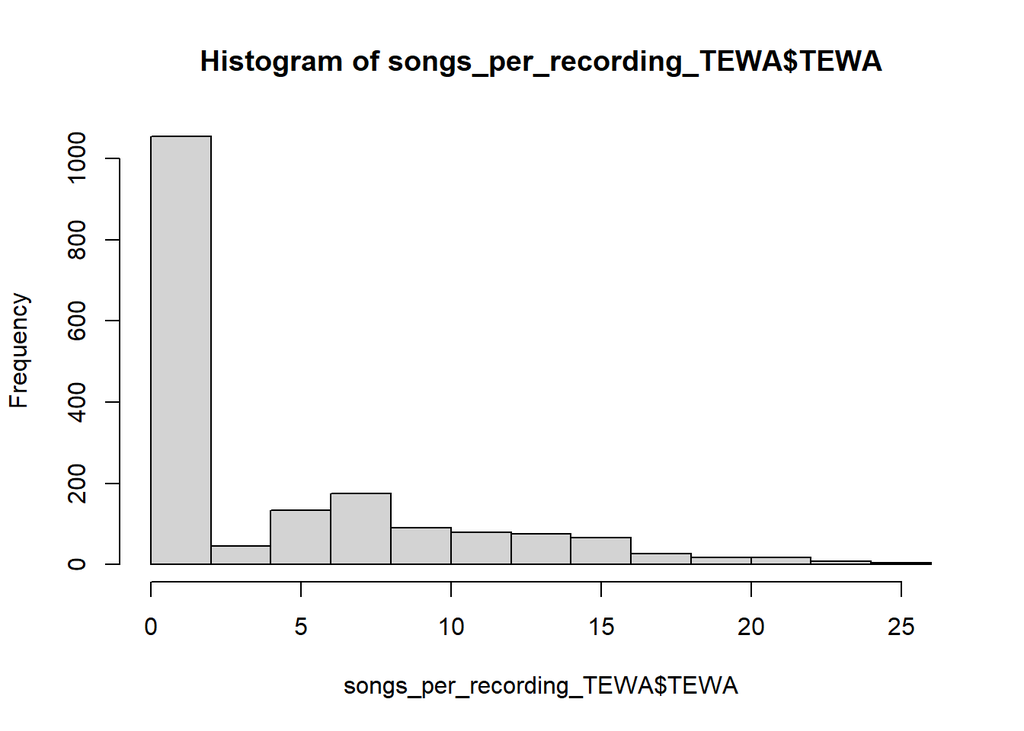

```r
hist(songs_per_recording_TEWA$TEWA)
```

```r
print(paste0("Mean TEWA song activity per recording: ", mean(songs_per_recording_TEWA$TEWA)))
```

```
## [1] "Mean TEWA song activity per recording: 4.19050279329609"
```

```r
print(paste0("Variance in TEWA song activity per recording: ", var(songs_per_recording_TEWA$TEWA)))
```

```
## [1] "Variance in TEWA song activity per recording: 33.863632502787"
```

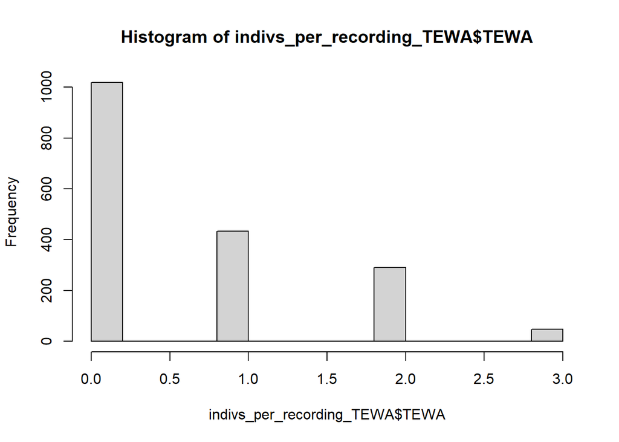

```r
hist(indivs_per_recording_TEWA$TEWA)
```

```r
print(paste0("Mean TEWA individuals per recording: ", mean(indivs_per_recording_TEWA$TEWA)))
```

```
## [1] "Mean TEWA individuals per recording: 0.646368715083799"
```

```r
print(paste0("Variance in TEWA individuals per recording: ", var(indivs_per_recording_TEWA$TEWA)))
```

```
## [1] "Variance in TEWA individuals per recording: 0.711655336304105"
```

Histogram suggests non-normal distributions of Tennessee Warbler song activity and number of individuals. Variance in song activity is much larger than mean value, suggesting that we should model it with a negative binomial distribution. Variance ~ mean for number of individuals, which could be modelled with a Poisson distribution.

```r
nlevels(as.factor(songs_per_recording_TEWA$latitude))#4
```

```
## [1] 11
```

```r
levels(as.factor(songs_per_recording_TEWA$latitude))
```

```
##  [1] "50.01807" "52.74722" "52.74762" "52.75639" "55.1348"  "55.2625"
##  [7] "56.86967" "57.87351" "58.28437" "59.2223"  "59.22269"
```

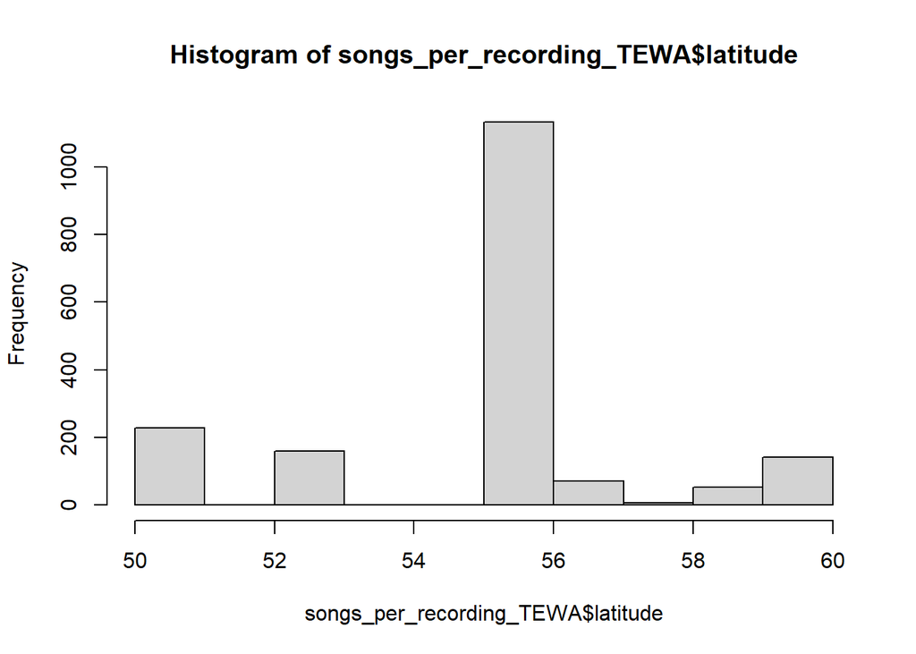

```r
#"53.789867" "59.411708" "59.417149" "60.03968"
hist(songs_per_recording_TEWA$latitude)
```

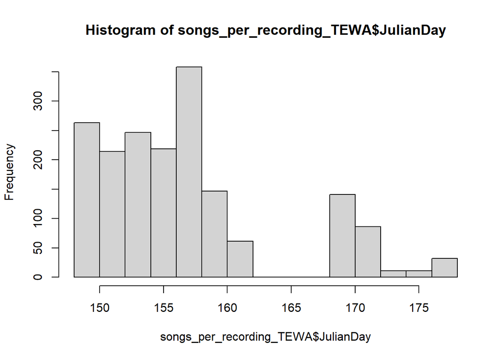

```r
hist(songs_per_recording_TEWA$JulianDay)
```

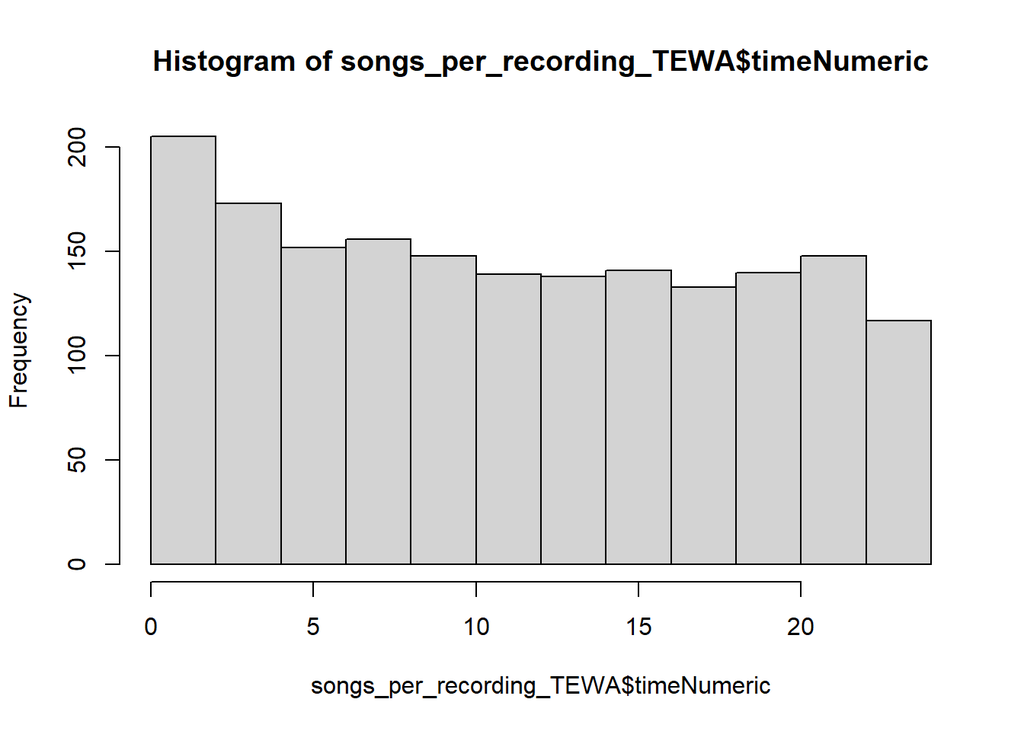

```r
hist(songs_per_recording_TEWA$timeNumeric)
```

**Box and Bar Plots**

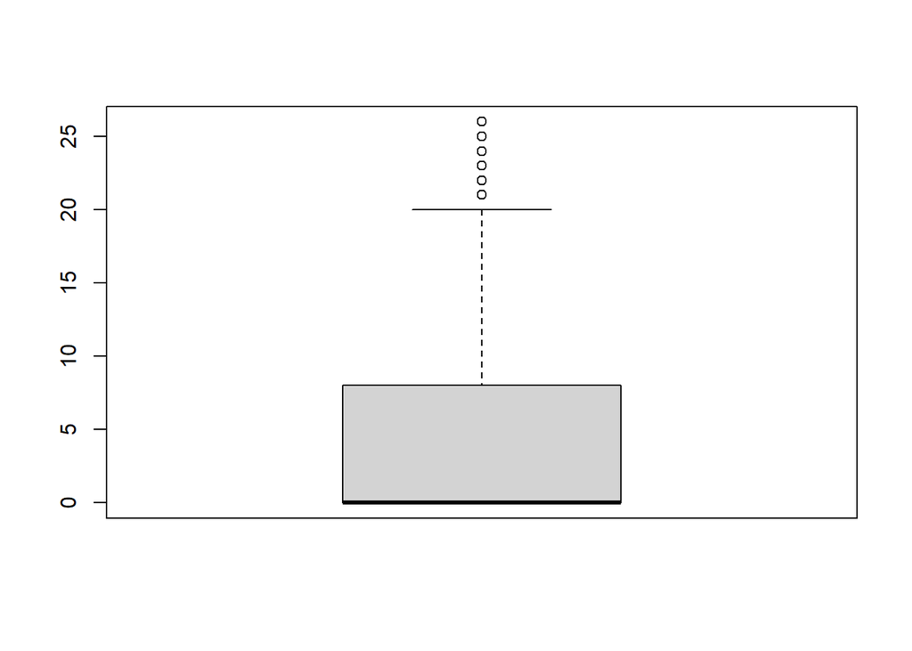

```r
boxplot(songs_per_recording_TEWA$TEWA)
```

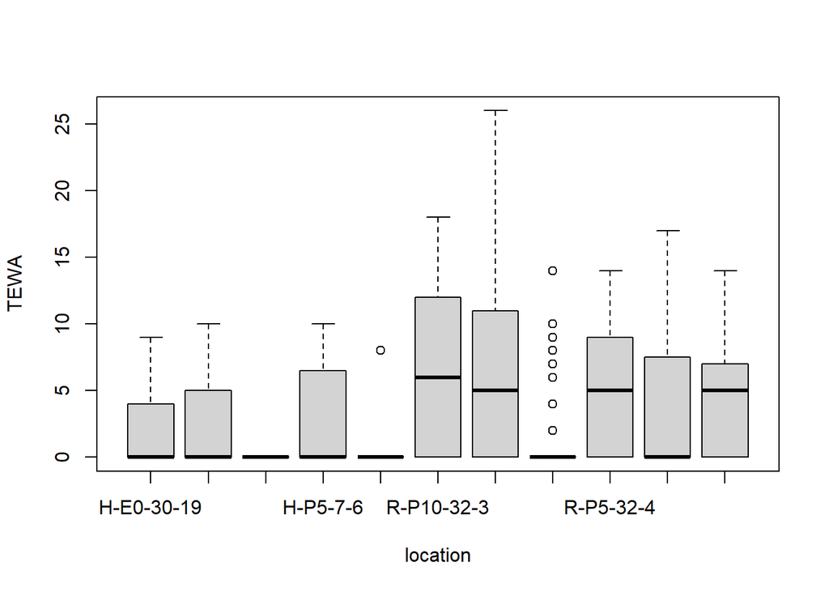

```r
boxplot(TEWA~location,
        data=songs_per_recording_TEWA)
```

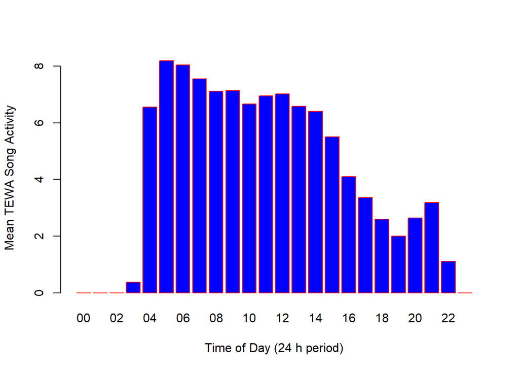

```r
TEWA_summ<-songs_per_recording_TEWA%>%
  group_by(Hour)%>%
  summarize(TEWA=mean(TEWA))
barplot(TEWA_summ$TEWA,
  xlab="Time of Day (24 h period)",
  names.arg=levels(as.factor(songs_per_recording_TEWA$Hour)),
  ylab="Mean TEWA Song Activity",
  border="red",
  col="blue")
```

**Scatter Plots**

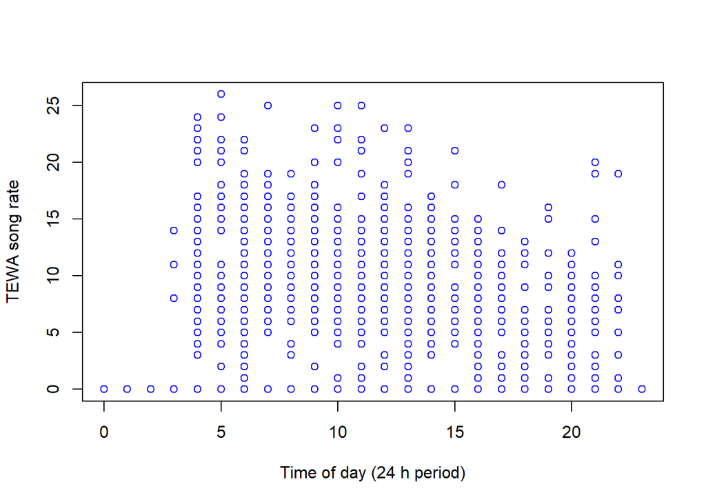

```r
plot(songs_per_recording_TEWA$Hour,
     songs_per_recording_TEWA$TEWA,
     ylab="TEWA song rate",
     xlab="Time of day (24 h period)",
     col="blue")
```

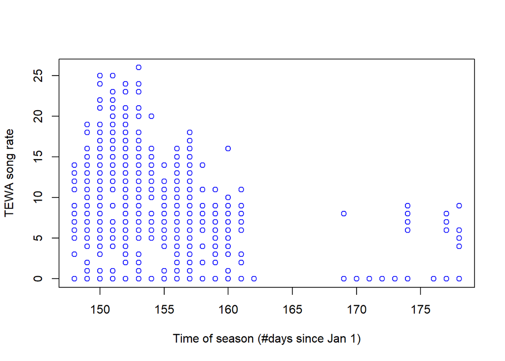

```r
plot(songs_per_recording_TEWA$JulianDay,
     songs_per_recording_TEWA$TEWA,
     ylab="TEWA song rate",
     xlab="Time of season (#days since Jan 1)",
     col="blue")
```

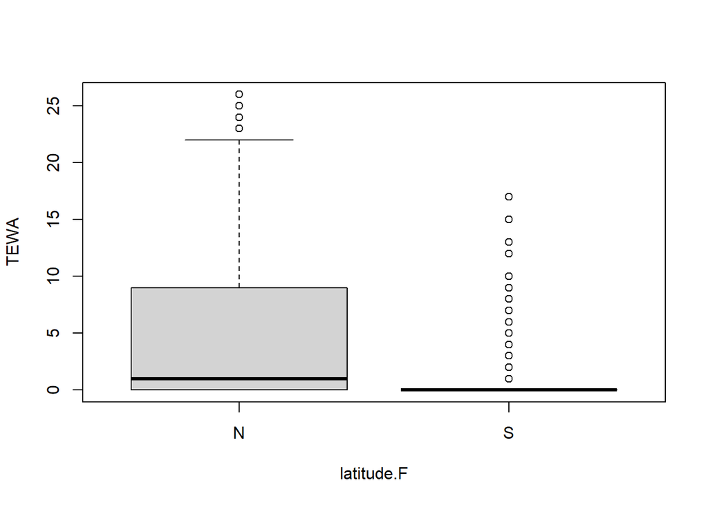

```r
songs_per_recording_TEWA$latitude.F<-as.factor(ifelse(songs_per_recording_TEWA$latitude<55,"S","N"))
boxplot(TEWA~latitude.F,
        data=songs_per_recording_TEWA)
```

**Run a Simple Model**

Data exploration suggested that Tennessee Warbler song activity varied slightly as a quadratic function of Julian day.

```r
songs_per_recording_TEWA$JDAY<-(songs_per_recording_TEWA$JulianDay-mean(songs_per_recording_TEWA$JulianDay))/sd(songs_per_recording_TEWA$JulianDay)

songs_per_recording_TEWA$JDAY2<-songs_per_recording_TEWA$JDAY^2

mod<-lm(TEWA~JDAY+JDAY2, data=songs_per_recording_TEWA)
summary(mod)
```

```
##
## Call:
## lm(formula = TEWA ~ JDAY + JDAY2, data = songs_per_recording_TEWA)
##
## Residuals:
##     Min      1Q  Median      3Q     Max
## -8.1676 -4.1171 -0.6799  3.2855 20.5368
##
## Coefficients:
##             Estimate Std. Error t value Pr(>|t|)
## (Intercept)   3.6201     0.1711  21.157  < 2e-16 ***
## JDAY         -2.7136     0.1849 -14.672  < 2e-16 ***
## JDAY2         0.5707     0.1137   5.022 5.63e-07 ***
## ---
## Signif. codes:  0 '***' 0.001 '**' 0.01 '*' 0.05 '.' 0.1 ' ' 1
##
## Residual standard error: 5.414 on 1787 degrees of freedom
## Multiple R-squared:  0.1355, Adjusted R-squared:  0.1345
## F-statistic:   140 on 2 and 1787 DF,  p-value: < 2.2e-16
```

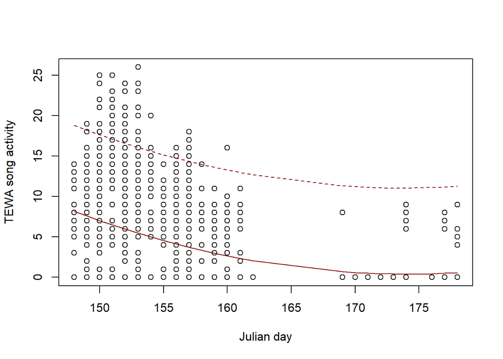

```r
#Get predicted values from linear regression
preds<-predict(mod, songs_per_recording_TEWA, se.fit = FALSE, scale = NULL, df = Inf,
        interval = c("prediction"),
        level = 0.95, type = c("response"))

songs_per_recording_TEWA.P<-cbind(songs_per_recording_TEWA,preds)

songs_per_recording_TEWA.P<-songs_per_recording_TEWA.P%>%
  arrange(JulianDay)

plot(songs_per_recording_TEWA.P$JulianDay,
     songs_per_recording_TEWA.P$TEWA,
     xlab="Julian day",
     ylab="TEWA song activity")
lines(songs_per_recording_TEWA.P$JulianDay,
     songs_per_recording_TEWA.P$fit, col="darkred")
lines(songs_per_recording_TEWA.P$JulianDay,
     songs_per_recording_TEWA.P$lwr, col="darkred", lty=2)
lines(songs_per_recording_TEWA.P$JulianDay,
     songs_per_recording_TEWA.P$upr, col="darkred", lty=2)
```

Regression results also suggested that Tennesse song activity varied as a quadratic function of Julian day, although a *bimodel distribution* is another possibility, and Julian day only explained a small amount of variance.

How well does the data meet the statistical assumptions of regression?

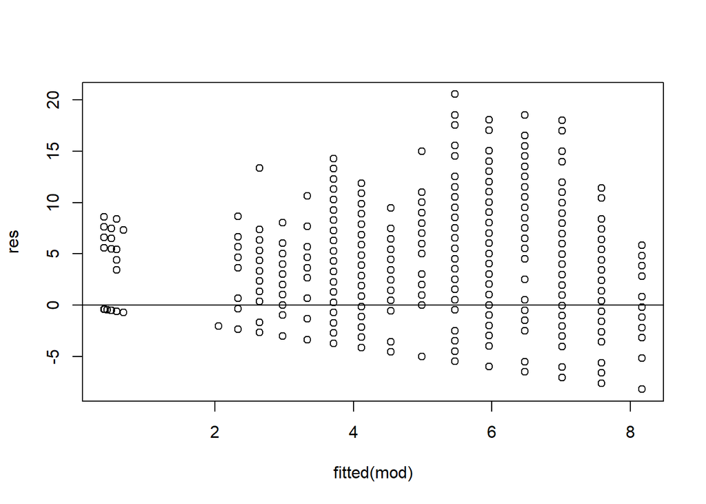

```r
res<-resid(mod)
plot(fitted(mod), res)
abline(0,0)
```

There is a lot of variance heterogeneity (bad!) since the *residuals* vary a lot more as the size of predicted values of song activity increase.

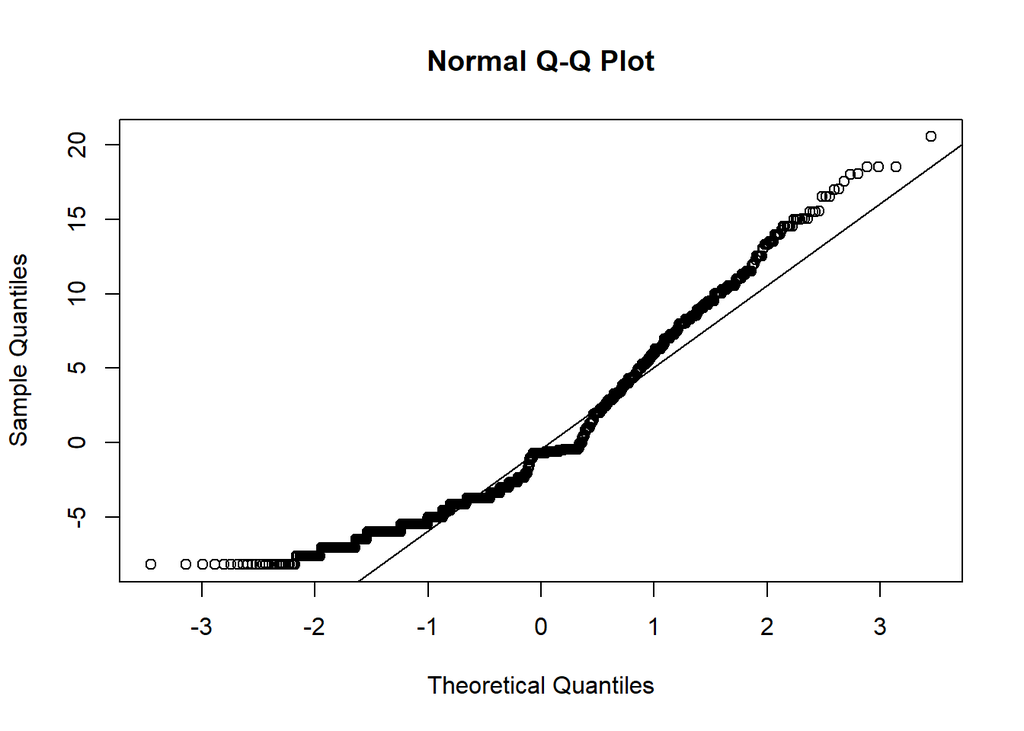

```r
qqnorm(res)#create a Q-Q plot for the residuals
qqline(res)#add a straight diagonal line to the plot
```

Larger predicted values’ residuals deviate from the Q-Q line, Though not that bad

We can try transforming the response variable to see if it improves the regression results but data independence will still be an issue.

```r
songs_per_recording_TEWA$TEWA.sq<-sqrt(songs_per_recording_TEWA$TEWA)
songs_per_recording_TEWA$TEWA.log<-log(songs_per_recording_TEWA$TEWA+0.1)

mod2<-lm(TEWA.sq~JDAY+JDAY2, data=songs_per_recording_TEWA)
summary(mod2)
```

```
##
## Call:
## lm(formula = TEWA.sq ~ JDAY + JDAY2, data = songs_per_recording_TEWA)
##
## Residuals:
##     Min      1Q  Median      3Q     Max
## -2.2833 -1.2126 -0.2939  1.3988  3.4545
##
## Coefficients:
##             Estimate Std. Error t value Pr(>|t|)
## (Intercept)  1.18859    0.04666   25.48  < 2e-16 ***
## JDAY        -0.69079    0.05043  -13.70  < 2e-16 ***
## JDAY2        0.10878    0.03099    3.51 0.000459 ***
## ---
## Signif. codes:  0 '***' 0.001 '**' 0.01 '*' 0.05 '.' 0.1 ' ' 1
##
## Residual standard error: 1.476 on 1787 degrees of freedom
## Multiple R-squared:  0.1323, Adjusted R-squared:  0.1314
## F-statistic: 136.3 on 2 and 1787 DF,  p-value: < 2.2e-16
```

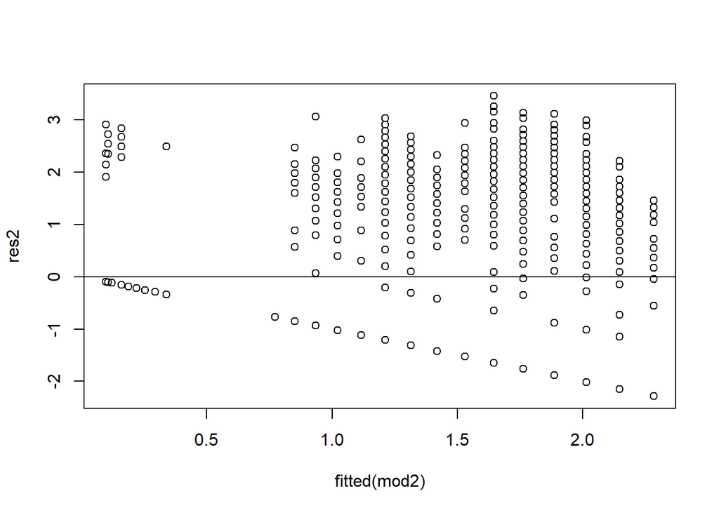

```r
res2<-resid(mod2)
plot(fitted(mod2), res2)
abline(0,0)
```

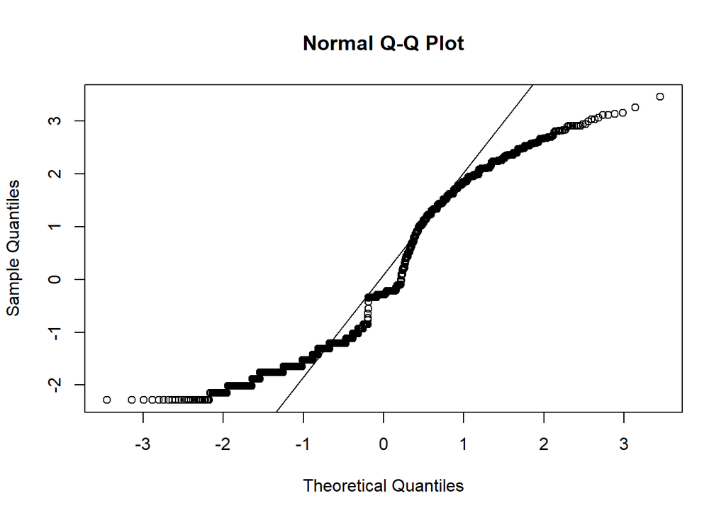

```r
qqnorm(res2)
qqline(res2)
```

```r
mod3<-lm(TEWA.log~JDAY+JDAY2, data=songs_per_recording_TEWA)
summary(mod3)
```

```
##
## Call:
## lm(formula = TEWA.log ~ JDAY + JDAY2, data = songs_per_recording_TEWA)
##
## Residuals:
##     Min      1Q  Median      3Q     Max
## -3.1631 -1.8395 -0.4578  2.2413  4.4347
##
## Coefficients:
##             Estimate Std. Error t value Pr(>|t|)
## (Intercept) -0.49412    0.06613  -7.472 1.23e-13 ***
## JDAY        -0.89472    0.07148 -12.517  < 2e-16 ***
## JDAY2        0.10420    0.04393   2.372   0.0178 *
## ---
## Signif. codes:  0 '***' 0.001 '**' 0.01 '*' 0.05 '.' 0.1 ' ' 1
##
## Residual standard error: 2.092 on 1787 degrees of freedom
## Multiple R-squared:  0.1224, Adjusted R-squared:  0.1215
## F-statistic: 124.7 on 2 and 1787 DF,  p-value: < 2.2e-16
```

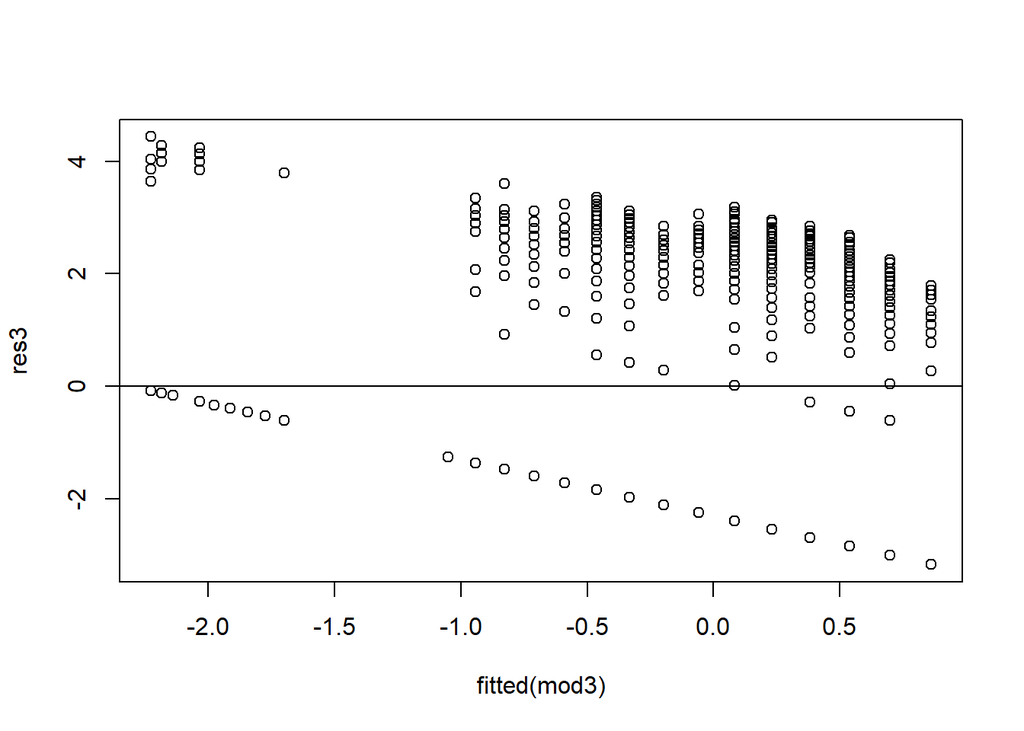

```r
res3<-resid(mod3)
plot(fitted(mod3), res3)
abline(0,0)
```

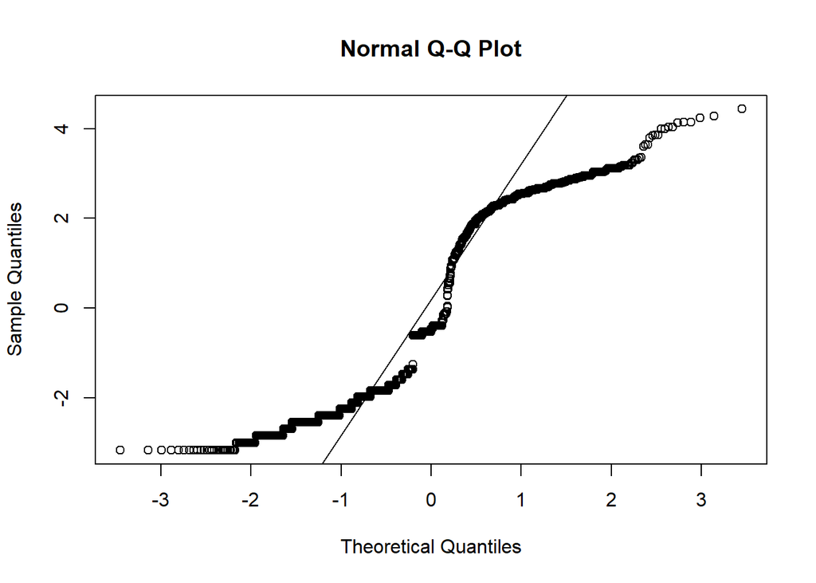

```r
qqnorm(res3)
qqline(res3)
```

A *generalized linear model* that assumes a non-normal error distribution in song activity might fit better.

```r
mod4<-glm(TEWA~JDAY+JDAY2, data=songs_per_recording_TEWA, family=quasipoisson(link = "log"))
summary(mod4)
```

```
##
## Call:
## glm(formula = TEWA ~ JDAY + JDAY2, family = quasipoisson(link = "log"),
##     data = songs_per_recording_TEWA)
##
## Deviance Residuals:
##    Min      1Q  Median      3Q     Max
## -4.058  -2.856  -1.184   1.481   7.206
##
## Coefficients:
##             Estimate Std. Error t value Pr(>|t|)
## (Intercept)  1.27687    0.04639  27.524   <2e-16 ***
## JDAY        -0.74564    0.05207 -14.320   <2e-16 ***
## JDAY2       -0.08565    0.04336  -1.975   0.0484 *
## ---
## Signif. codes:  0 '***' 0.001 '**' 0.01 '*' 0.05 '.' 0.1 ' ' 1
##
## (Dispersion parameter for quasipoisson family taken to be 7.284961)
##
##     Null deviance: 14594  on 1789  degrees of freedom
## Residual deviance: 12253  on 1787  degrees of freedom
## AIC: NA
##
## Number of Fisher Scoring iterations: 7
```

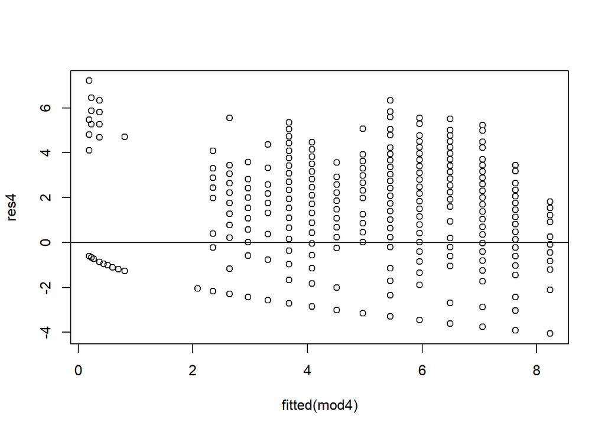

```r
res4<-resid(mod4)
plot(fitted(mod4), res4)
abline(0,0)
```

```r
pseudo.R2<-(mod4$null.deviance-mod4$deviance)/mod4$null.deviance
print(paste0("Pseudo-R2 or percent deviance explained: ", pseudo.R2))
```

```
## [1] "Pseudo-R2 or percent deviance explained: 0.160402785371333"
```

There is some variance heterogeneity still but less than with linear regression and the pseudo-R2 (proportion of explained deviance) 0.1604028 is greater than the R2 explained by the regression.

Data exploration suggests that Tennesse song activity varies as a more complex function of day and night. Use a more complex model like a generalized additive model or a circular function.

```r
library(mgcv)
#library(gamm4)
thetaval=(var(songs_per_recording_TEWA$TEWA)/mean(songs_per_recording_TEWA$TEWA))

songs_per_recording_TEWA$TIME<-(songs_per_recording_TEWA$timeNumeric-mean(songs_per_recording_TEWA$timeNumeric))/sd(songs_per_recording_TEWA$timeNumeric)

GAM1 <- gam(TEWA ~s(JDAY, k = 3, bs = "cs") + s(TIME, k = 5, bs = "cs"),  data=songs_per_recording_TEWA, family=negbin(theta=thetaval, link="log"))

coef.gammB<-coef(GAM1)
#model.matrix(GAM1)
```

We can also check output from GAMs for potential data violations.

```r
print("GAM1 Check:")
```

```
## [1] "GAM1 Check:"
```

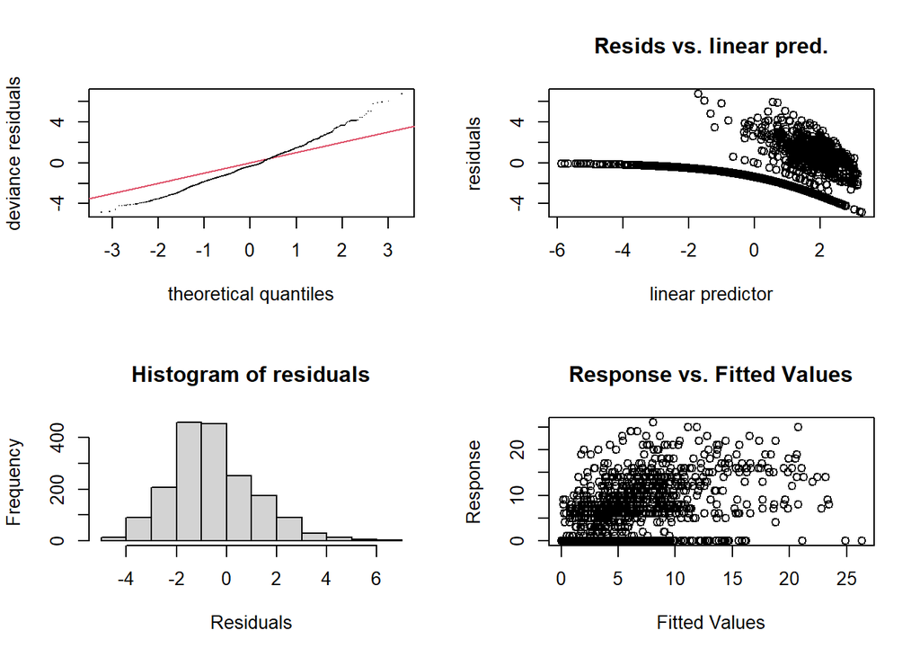

```
##
## Method: UBRE   Optimizer: outer newton
## full convergence after 8 iterations.
## Gradient range [2.205238e-07,4.767942e-06]
## (score 2.082752 & scale 1).
## Hessian positive definite, eigenvalue range [1.286175e-05,0.0002437708].
## Model rank =  7 / 7
##
## Basis dimension (k) checking results. Low p-value (k-index<1) may
## indicate that k is too low, especially if edf is close to k'.
##
##           k'  edf k-index p-value
## s(JDAY) 2.00 1.79    0.37  <2e-16 ***
## s(TIME) 4.00 4.00    0.67  <2e-16 ***
## ---
## Signif. codes:  0 '***' 0.001 '**' 0.01 '*' 0.05 '.' 0.1 ' ' 1
```

```r
gam.check(GAM1)
```

Create a prediction dataset for GAMs

```r
timeNumeric=seq(from=0,to=23.95,by=0.05)
JulianDay=seq(from=113,to=240,by=1)
TIME=(timeNumeric-mean(timeNumeric))/sd(timeNumeric)
JDAY=(JulianDay-mean(JulianDay))/sd(JulianDay)

#songs_per_recording[songs_per_recording$timeNumeric==5,]
TEWA.tsss.jd<-expand.grid(intercept=1,
                             #latitude.F=c("N","S"),
                             TIME=-0.5254806, #scaled value associated with timeNumeric=5.00
                             JDAY=as.numeric(levels(as.factor(JDAY)))
)

#get model matrix for GAM2 based on these variables in prediction dataset
TEWA.tsss.jdmm <- model.matrix(GAM1, TEWA.tsss.jd)

## predict and apply inverse link function: this gives a new matrix
TEWA.gam.pred <- (exp(TEWA.tsss.jdmm %*% coef.gammB))#take antilog?
Preds<-data.frame(TEWA.gam.pred)
```

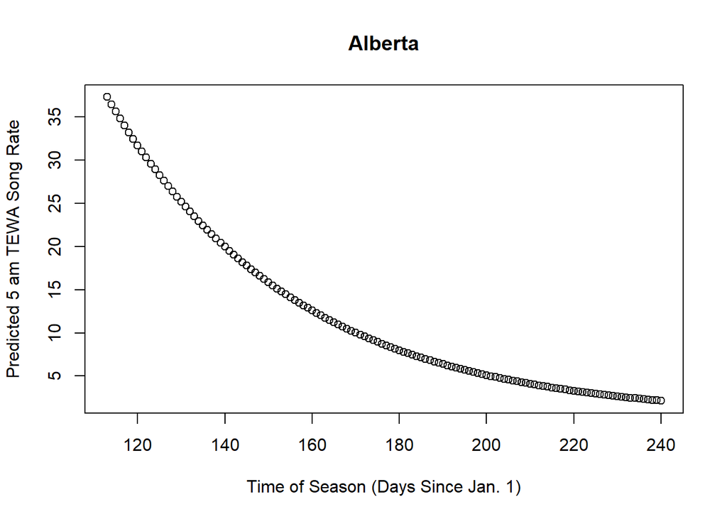

```r
plotData<-cbind(TEWA.tsss.jd, Preds)
plotData<-data.frame(plotData)
#write.csv(plotData, file="output/GAMdatacheck.csv")
# plotDataN.time5<-plotData%>%
#   filter(latitude.F=="N")
plotData$timeNumeric<-5.0
plotData$JulianDay<-JulianDay

plot(plotData$JulianDay,
     plotData$TEWA.gam.pred,
     xlab="Time of Season (Days Since Jan. 1)",
     ylab="Predicted 5 am TEWA Song Rate",
     main="Alberta")
```

```r
# plotDataS.time5<-plotData%>%
#   filter(latitude.F=="S")
# plotDataS.time5$timeNumeric<-5.0
# plotDataS.time5$JulianDay<-JulianDay
#
# plot(plotDataS.time5$JulianDay,
#      plotDataS.time5$swth.gam.pred,
#      xlab="Time of Season (Days Since Jan. 1)",
#      ylab="Predicted 5am SWTH Song Rate",
#      main="Southern Alberta")
```

```r
timeNumeric=seq(from=0,to=23.95,by=0.05)
JulianDay=seq(from=113,to=240,by=1)
TIME=(timeNumeric-mean(timeNumeric))/sd(timeNumeric)
JDAY=(JulianDay-mean(JulianDay))/sd(JulianDay)

#songs_per_recording[songs_per_recording$JulianDay==180,]
TEWA.tsss.jd2<-expand.grid(intercept=1,
                             #latitude.F=c("N","S"),
                             TIME=as.numeric(levels(as.factor(TIME))),
                             JDAY=-1.18#scaled value associated with JulianDay=150
)

#get model matrix for GAM2 based on these variables in prediction dataset
TEWA.tsss.jdmm2 <- model.matrix(GAM1, TEWA.tsss.jd2)

## predict and apply inverse link function: this gives a new matrix
TEWA.gam.pred2 <- (exp(TEWA.tsss.jdmm2 %*% coef.gammB))#take antilog?
Preds2<-data.frame(TEWA.gam.pred2)
```

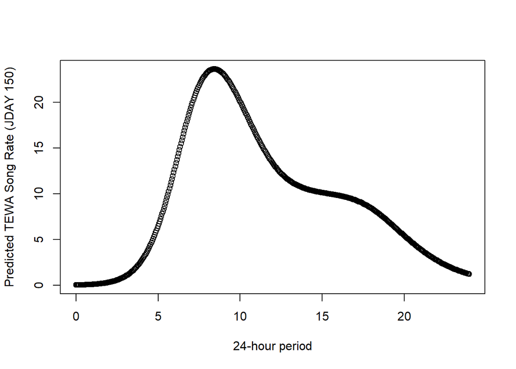

```r
plotData<-cbind(TEWA.tsss.jd2, Preds2)
plotData<-data.frame(plotData)
#write.csv(plotData, file="output/GAMdatacheck.csv")
# plotDataN.time5<-plotData%>%
#   filter(latitude.F=="N")
plotData$timeNumeric<-timeNumeric
plotData$JulianDay<-150

plot(plotData$timeNumeric,
     plotData$TEWA.gam.pred2,
     xlab="24-hour period",
     ylab="Predicted TEWA Song Rate (JDAY 150)")
```

```r
# plotDataS.time5<-plotData%>%
#   filter(latitude.F=="S")
# plotDataS.time5$timeNumeric<-timeNumeric
# plotDataS.time5$JulianDay<-150
#
# plot(plotDataS.time5$timeNumeric,
#      plotDataS.time5$swth.gam.pred,
#      xlab="24-hour period",
#      ylab="Predicted TEWA Song Rate (JDAY 180)")
```

Predicted effects of time of day look discontinuous at extreme values (0 hrs and 23 hrs). A circular function might be better.

```r
GAM3 <- gam(TEWA ~s(JDAY, bs = "cs", k=3) + s(TIME, bs = "cc"), data=songs_per_recording_TEWA, family=negbin(theta=thetaval, link="log"))
#cc=a cyclic cubic spline used for TIME
#removed the specification for the number of knots; a larger number of knots is used for both the JDAY and TIME basis functions

coef.gammB3<-coef(GAM3)
#model.matrix(GAM2$gam)
coef.gammB3
```

```
## (Intercept)   s(JDAY).1   s(JDAY).2   s(TIME).1   s(TIME).2   s(TIME).3
##   0.4906309  -1.0108013  -2.4266726  -1.0423383   2.3867457   1.9530755
##   s(TIME).4   s(TIME).5   s(TIME).6   s(TIME).7   s(TIME).8
##   2.0151742   1.7673169   1.5839647   0.5336024   1.0484186
```

```r
print("AIC:")
```

```
## [1] "AIC:"
```

```r
AIC(GAM1, GAM3)
```

```
##             df      AIC
## GAM1  6.783415 9179.204
## GAM3 10.758163 8692.041
```

```r
print("GAM3 Check:")
```

```
## [1] "GAM3 Check:"
```

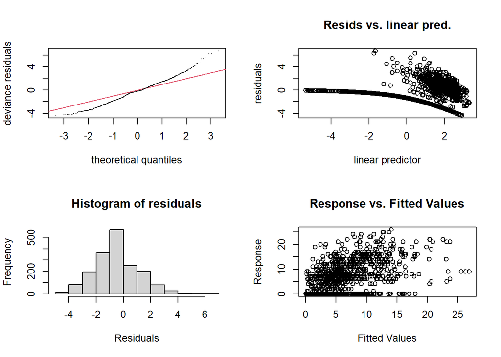

```
##
## Method: UBRE   Optimizer: outer newton
## full convergence after 7 iterations.
## Gradient range [3.233001e-07,2.048025e-06]
## (score 1.810594 & scale 1).
## Hessian positive definite, eigenvalue range [2.337383e-05,0.0002660458].
## Model rank =  11 / 11
##
## Basis dimension (k) checking results. Low p-value (k-index<1) may
## indicate that k is too low, especially if edf is close to k'.
##
##           k'  edf k-index p-value
## s(JDAY) 2.00 1.78    0.39  <2e-16 ***
## s(TIME) 8.00 7.98    0.73  <2e-16 ***
## ---
## Signif. codes:  0 '***' 0.001 '**' 0.01 '*' 0.05 '.' 0.1 ' ' 1
```

```r
gam.check(GAM3)
```

```r
timeNumeric=seq(from=0,to=23.95,by=0.05)
JulianDay=seq(from=113,to=240,by=1)
TIME=(timeNumeric-mean(timeNumeric))/sd(timeNumeric)
JDAY=(JulianDay-mean(JulianDay))/sd(JulianDay)

#songs_per_recording_TEWA[songs_per_recording$timeNumeric==5,]
TEWA.tsss.jd<-expand.grid(intercept=1,
                             TIME=-0.5254806, #scaled value associated with timeNumeric=5.00
                             JDAY=as.numeric(levels(as.factor(JDAY)))
)

#get model matrix for GAM2 based on these variables in prediction dataset
TEWA.tsss.jdmm <- model.matrix(GAM3, TEWA.tsss.jd)

## predict and apply inverse link function: this gives a new matrix
TEWA.gam.pred <- (exp(TEWA.tsss.jdmm %*% coef.gammB3))#take antilog?
Preds<-data.frame(TEWA.gam.pred)
```

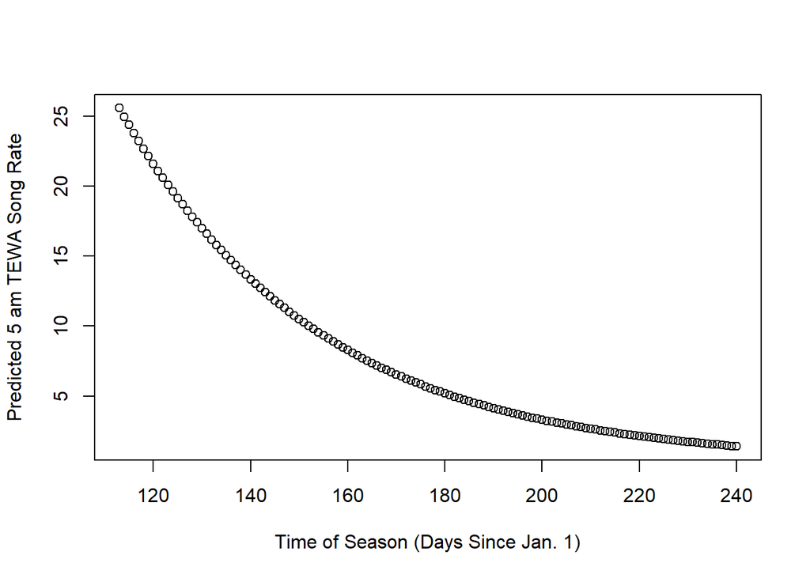

```r
plotData<-cbind(TEWA.tsss.jd, Preds)
plotData<-data.frame(plotData)
#write.csv(plotData, file="output/GAMdatacheck.csv")
plotData$timeNumeric<-5.0
plotData$JulianDay<-JulianDay

plot(plotData$JulianDay,
     plotData$TEWA.gam.pred,
     xlab="Time of Season (Days Since Jan. 1)",
     ylab="Predicted 5 am TEWA Song Rate")
```

Now plot the effect of time of day/night, using a circular function of time.

```r
timeNumeric=seq(from=0,to=23.95,by=0.05)
JulianDay=seq(from=113,to=240,by=1)
TIME=(timeNumeric-mean(timeNumeric))/sd(timeNumeric)
JDAY=(JulianDay-mean(JulianDay))/sd(JulianDay)

#songs_per_recording[songs_per_recording$JulianDay==180,]
TEWA.tsss.jd2<-expand.grid(intercept=1,
                             TIME=as.numeric(levels(as.factor(TIME))),
                             JDAY=-1.18#scaled value associated with JulianDay=150
)

#get model matrix for GAM2 based on these variables in prediction dataset
TEWA.tsss.jdmm2 <- model.matrix(GAM3, TEWA.tsss.jd2)

## predict and apply inverse link function: this gives a new matrix
TEWA.gam.pred2 <- (exp(TEWA.tsss.jdmm2 %*% coef.gammB3))#take antilog?
Preds2<-data.frame(TEWA.gam.pred2)
```

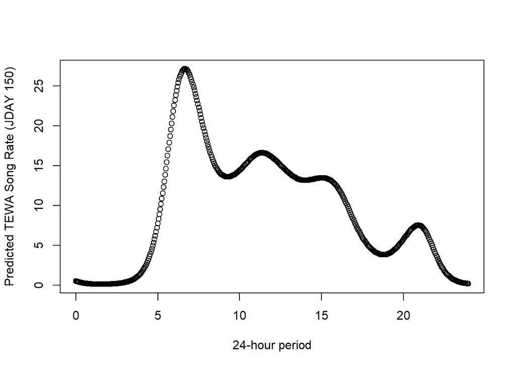

```r
plotData<-cbind(TEWA.tsss.jd2, Preds2)
plotData<-data.frame(plotData)
#write.csv(plotData, file="output/GAMdatacheck.csv")
plotData$timeNumeric<-timeNumeric
plotData$JulianDay<-150

plot(plotData$timeNumeric,
     plotData$TEWA.gam.pred,
     xlab="24-hour period",
     ylab="Predicted TEWA Song Rate (JDAY 150)")
```

Try bootstrap. Note that the code chunk below has been set to *eval=FALSE*, so that it isn’t executed when the Markdown document is knitted.

```r
table(songs_per_recording_TEWA$location)#955 recordings from the one location

fSampleNint <- function(dat) {
  dat %>%
    group_by(location)%>%
    sample_n(100, replace=TRUE)
}#creates a sample of 100 observations from the dataset
d1<-fSampleNint(songs_per_recording_TEWA)
d2<-fSampleNint(songs_per_recording_TEWA)
d3<-fSampleNint(songs_per_recording_TEWA)

bs <- function(data, indices){#
  d<-fSampleNint(data)#, PKEY, 1
  #return(d$PKEY)
  try(GAM3 <- gam(TEWA ~s(JDAY, bs = "cs") + s(TIME, bs = "cc"), data=d, family=negbin(theta=thetaval, link="log")))
  try(coef.gamm<-coef(GAM3))
  try(return(coef.gamm))
}

library(boot)
a<-Sys.time()
songresults <- boot(data=songs_per_recording_TEWA,
                    statistic=bs, parallel="multicore",
                    R=100)
b<-Sys.time()
print(b-a)

CoefB <-t(songresults$t)
#get rid of columns with errors
CoefB<-data.frame(CoefB)
CoefB[] <- lapply(CoefB, function(x) as.numeric(as.character(x)))
#delete columns with NA values
all_na <- function(x) any(!is.na(x))
CoefB<-CoefB %>% select_if(all_na)
CoefB<-as.matrix(CoefB)
ncol(CoefB)
CoefBCI50 <- t(apply(CoefB, 1, quantile, c(0.5, 0.25, 0.75), na.rm=TRUE))
CoefBCI90 <- t(apply(CoefB, 1, quantile, c(0.5, 0.05, 0.95), na.rm=TRUE))
save(songresults, CoefB, CoefBCI50, CoefBCI90, file="output/boot100_TEWA_Aug2.RData")
```

Plot bootstrapped model results. Note that the code chunk below has been set to *eval=FALSE*, so that it isn’t executed when the Markdown document is knitted.

```r
load("output/boot100_TEWA_Aug2.RData")
songs_per_recording_TEWA$date<-substr(songs_per_recording_TEWA$recording_date_time,1,10)
dates<-data.frame(unique(songs_per_recording_TEWA[,c("date","JulianDay","JDAY")]))
date_times<-data.frame(unique(songs_per_recording_TEWA[,c("date","JulianDay","JDAY","timeNumeric","TIME")]))

for (i in 1:nrow(dates)){
  Day<-dates[i,1]
  ordinal.day<-dates[i,2]
  songs.tsss.jd<-expand.grid(intercept=1,
                             timeNumeric=seq(from=0,to=23.66667,by=(1/3)),
                             JulianDay=seq(from=148,to=162,by=1)
  )
  songs.tsss.jd$JDAY<-(songs.tsss.jd$JulianDay-mean(songs.tsss.jd$JulianDay))/sd(songs.tsss.jd$JulianDay)
  songs.tsss.jd$TIME<-(songs.tsss.jd$timeNumeric-mean(songs.tsss.jd$timeNumeric))/sd(songs.tsss.jd$timeNumeric)

  #Now limit predictions to those from a single date
  songs.tsss.jd<-songs.tsss.jd[songs.tsss.jd$JulianDay==ordinal.day,]

  JulianDay<-songs.tsss.jd$JulianDay
  timeNumeric<-songs.tsss.jd$timeNumeric
  str(songs.tsss.jd)
  names(songs.tsss.jd)

  songs.tsss.jdmm <- model.matrix(GAM3, songs.tsss.jd)#meantemp.s+moon.s+

  ## predict and apply inverse link function: this gives an n_new x B+1 matrix
  songpreds100 <- (exp(songs.tsss.jdmm %*% CoefB))#take antilog?

  ## calculate median and 95% CIs for predictions
  bp100.CI95 <- t(apply(songpreds100, 1, quantile, seq(from=0.025, to=0.975, by=((0.975-0.025)/95)), na.rm=TRUE))

  ## Use these bootstrapped predictions to generate heat maps, 3d plots, etc.

  songs.tsss.jd.bci<-cbind(songs.tsss.jd, bp100.CI95)
  songs.tsss.jd.bci$date<-Day

    preds.025.975<-songs.tsss.jd.bci[,6:101]
    for (k in 1:ncol(preds.025.975)){
      preds.025.975[,k]<-ifelse(preds.025.975[,k]>600,600,preds.025.975[,k])
    }
    tiff(paste0("output/matrix plots/TEWAsongrateXtime-",Day,".tiff"), units="in", width=6, height=4, res=300)
    matplot(songs.tsss.jd.bci$timeNumeric,
            preds.025.975,
            type="l", cex.axis=1.5, cex.lab=1.5,
            col="blue",#cividis(100),
            xlab="Time (24-h period)",
            #xlim=rev(range(preds.sitelevel$TSSS.hr)),
            ylim=c(0,70),
            ylab="# Tennessee Warbler Songs",
            main=paste0(Day))
    dev.off()
}
```